# IODS course project

Otso Perakyla

# This is the Introduction to Open Data Science course diary for week 1

*In this course, I will learn to use all kinds of cool tools, including R, R markdown and Git(Hub)*

My project can be found [here](https://www.youtube.com/watch?v=dQw4w9WgXcQ). If that link does not work for some reason, it is as well [here](https://github.com/otsopera/IODS-project)

# Chapter 2: Regression analysis

*Performing regression analysis on the Learning 2014 data*

- We’ll use the data wrangled in the first part of exercise 2: the full description of the data can be found [here](http://www.helsinki.fi/~kvehkala/JYTmooc/JYTOPKYS3-meta.txt)
- The data is collected on a statistics course in 2014, and describest the students’ attitudes to learning, as well as background info on the students and the students’ course scores. The students who did not attend the exam have been discarded from the analyses.

Below you can see some descriptive figures on the data.

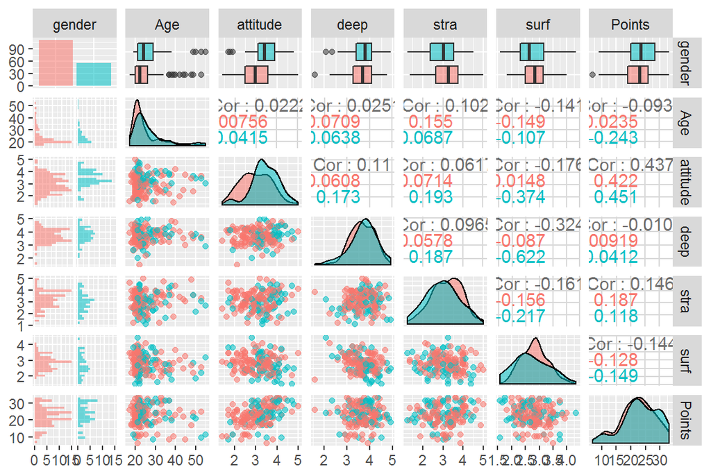

```r
# read the data
lrn14_analysis <- read.table("./data/learning2014.txt",header = T,  dec = ".")

# load visualization libraries
library(GGally)
library(ggplot2)

# make cool plot
p <- ggpairs(lrn14_analysis, mapping = aes(col = gender, alpha = 0.3), lower = list(combo = wrap("facethist", bins = 20)))
p
```

```r
summary(lrn14_analysis)
```

```
##  gender       Age           attitude          deep            stra
##  F:110   Min.   :17.00   Min.   :1.400   Min.   :1.583   Min.   :1.250
##  M: 56   1st Qu.:21.00   1st Qu.:2.600   1st Qu.:3.333   1st Qu.:2.625
##          Median :22.00   Median :3.200   Median :3.667   Median :3.188
##          Mean   :25.51   Mean   :3.143   Mean   :3.680   Mean   :3.121
##          3rd Qu.:27.00   3rd Qu.:3.700   3rd Qu.:4.083   3rd Qu.:3.625
##          Max.   :55.00   Max.   :5.000   Max.   :4.917   Max.   :5.000
##       surf           Points
##  Min.   :1.583   Min.   : 7.00
##  1st Qu.:2.417   1st Qu.:19.00
##  Median :2.833   Median :23.00
##  Mean   :2.787   Mean   :22.72
##  3rd Qu.:3.167   3rd Qu.:27.75
##  Max.   :4.333   Max.   :33.00
```

As you can see, there are about twice as many females compared to males. Judging from the distributions of the variables, there are a few differences between males and females (the overlaid distribution plots on the diagonal). The distribution of ages is similar with both genders: a peak at around 20 years, and a long tail to the older ages. Attitude shows the first difference: the females’ attitudes vary more widely (as is clear from the wider distribution), and peak at lower values. Deep learning is relatively similar. With strategic learning, the females’ scores peak at a higher value. With the surface learning, the difference is the opposite to the attitude: males’ scores differ more widely, and females in general have a higher score. With the points the disrtibutions are very similar, with one key difference: there is a group of males with very high points. This separate group is not present in the females’ distributions. Judging from the correlations (the numbers above the diagonal), there are mainly no strong dependencies between the variables (most of the correlations are below 0.2). There are again a few exceptions. Attitudes and points seems to show a positive correlation, in both genders. Interestingly, within males the deep and surface learning are anticorrelated relatively strongly, while females show next to no correlation. Still, all of these interpretations are very preliminary: at least bigger figures, if not aome statistical testing, would be required to confirm them.